# Introduktion

## Mora

Mora kommun är Dalarnas femte största sett till folkmängd och hade år 2022 drygt 20 600 invånare. Fram till 1990 ökade befolkningen avsevärt, men har därefter mer eller mindre stått still. Moras arbetslöshet, ca 2 procent, är klart under genomsnittet i Dalarna och dessutom har kommunen den tredje största andelen högutbildade. Den låga arbetslösheten kan delvis förklaras med att Mora har en relativt sett lägre andel utrikes födda i befolkningen, än i många andra Dalakommuner. Arbetslösheten har visat sig vara genomgående högre bland utrikes födda än bland inrikes födda. Vidare är Mora en kommun som många pendlar till, ungefär var fjärde förvärvsarbetande bor inte i kommunen.

Mora har ursprung från medeltiden och är idag kanske mest känt för Vasaloppet och Anders Zorn. Mer än var fjärde förvärvsarbetande arbetar inom vård och omsorg, vilket är en klart högre andel än genomsnittet i Dalarna. Detta beror till stor del på att ett av Dalarnas centralsjukhus, Mora lasarett, ligger i kommunen. I övrigt är andelen förvärvsarbetande per bransch ungefär i linje med snittet för Dalarna.

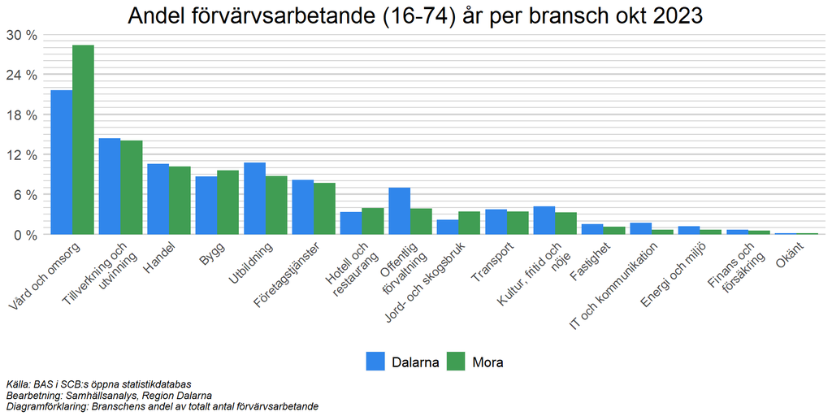

Bland arbetsgivare inom det privata näringslivet är branschgruppen byggindustri den största, såväl vad gäller sysselsatta som andel av den totala lönesumman (15 procent). Även företag inom metallvaruindustri, parti- och detaljhandel samt företagsservicefirmor är viktiga arbetsgivare, med närmare 40 procent av den totala lönesumman tillsammans. Av dessa branschgrupper har parti och detaljhandel en jämnställd könsfördelning, medan många inom företagsservicefirmor (34 procent) har eftergymnasial utbildning.

Den största arbetsgivaren i Mora var 2021 Mora Kommun med runt 1 800 anställda. Många i Mora jobbar även för Region Dalarna, medan FM Mattsson är den största privata arbetsgivaren med ungefär 300 anställda.

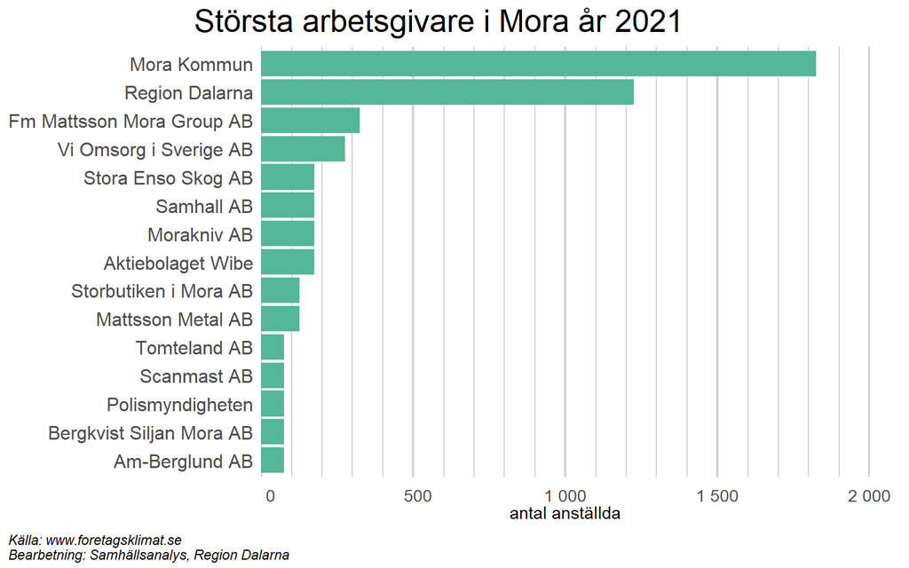

Precis som många andra kommuner i norra Dalarna har Mora ett stort antal arbetsställen i förhållande till sin befolkning, vilket är en indikation på ett väl fungerande företagande i kommunen.

Mora har dessutom en relativt stor branschbredd (3:e bästa i Dalarna) och rankar högt på antal företag som krävs för att lönesumman skall överstiga 50 procent (4:e bästa i Dalarna) inom det privata näringslivet, vilket indikerar att beroendet i kommunen är lågt. Samtidigt är, som nämnts tidigare, vård och omsorg en viktig arbetsgivare och på exempelvis Mora lasarett jobbar runt 1 000 personer.

Sammanfattningsvis uppvisar Mora låg sårbarhet på de flesta områden i den modell vi använder. Arbetslösheten är låg och utbildningsnivån hög, samtidigt som beroendet av enskilda branscher och företag inom det privata näringslivet är lågt. Den riskfaktor som kan skönjas, precis som var fallet med Falun, är det relativt stora beroendet av företag inom vård och omsorg, i mångt och mycket kopplat till Mora lasarett.

## Orsa

Orsa kommun, med ca 7 000 invånare, var Dalarnas näst minsta kommun år 2022. Folkmängden har varit relativt konstant under en lång tid och på senare år har en nedgång i antalet invånare som är födda i Sverige kompenserats av en ökad invandring. Arbetslösheten i Orsa, 4.1 procent, är något under genomsnittet i Dalarna, men andelen högutbildade är klart lägre än genomsnittet. I jämförelse med vissa andra kommuner i norra Dalarna har dock Orsa en klart högre arbetslöshet, vilket bara delvis kan tillskrivas en något högre andel utrikes födda invånare. Exempelvis är andelen utrikes födda invånare i Orsa och Malung-Sälen på ungefär samma nivå (ca 12 procent), men samtidigt är arbetslösheten i Malung-Sälen klart lägre än i Orsa. Pendlingen från Orsa till andra kommuner är hög och nästan varannan som bor i Orsa och förvärvsarbetar gör så i en annan kommun, vilket är positivt för arbetsmarknadens resiliens mot kriser. Medelåldern i Orsa, strax över 46 år, är förhållandevis hög.

Av de som förvärvsarbetar i Orsa gör mer än var femte det inom vård och omsorg, vilket är en större andel än genomsnittet för Dalarna. I jämförelse med Dalarna sticker även byggindustrin ut, med runt 18 procent av de förvärvsarbetande, även jord- och skogsbruk (6 procent) och kultur m.m. (ca 5 procent) står för en stor andel av de sysselsatta. Den sistnämnda branschen innefattar sannolikt många personer som arbetar inom turism (Orsa-Grönklitt).

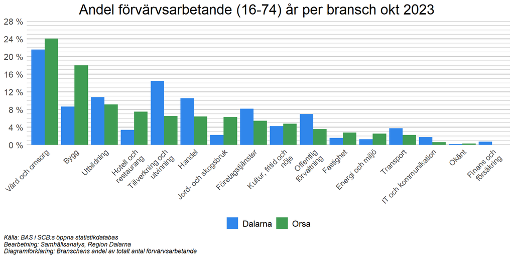

Inom det privata näringslivet utgör företag inom byggindustri den klart största andelen, och står för 27 procent av den totala lönesumman. Anmärkningsvärt är att bara 3 procent av de ca 430 anställda är utrikes födda. Bland övriga större branscher återfinns bland annat renhållning, kultur och sport m.m., vilken innefattar företag i turismindustrin, och då framförallt Orsa-Grönklitt.

Den största arbetsgivaren i Orsa var 2021 Orsa Kommun med runt 600 anställda. Bland privata arbetsgivare hade Transdev, som under 2021 köpte Siljans buss, flest anställda med drygt 200.

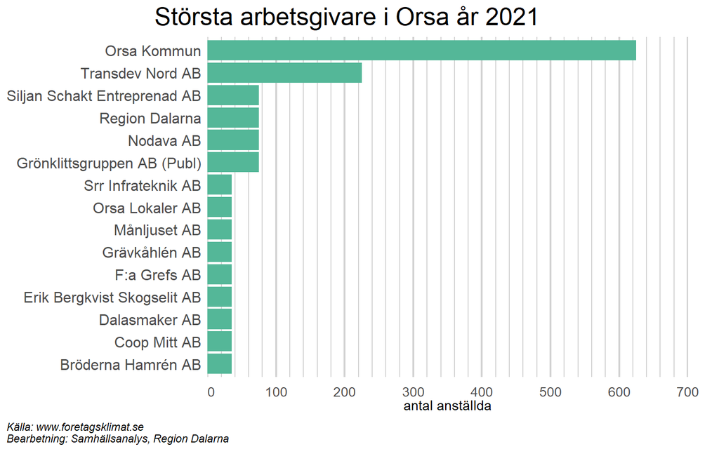

Orsa är som sagt en av Dalarnas minsta kommuner sett till folkmängd och har följaktligen en relativt låg branschbredd. Samtidigt är antalet företag som krävs för att den aggregerade lönesumman skall uppgå till 50 procent av den totala lönesumman (inom det privata näringslivet) högre än ett par befolkningsmässigt större kommuner i Dalarna. Vidare startas det relativt få nya företag i Orsa och antalet konkurser har ökat stadigt på senare år.

Sammanfattningsvis kan Orsa sägas vara en kommun som uppvisar både sårbara och inte sårbara sidor. Arbetslösheten är under genomsnittet i Dalarna och en stor utpendling minskar arbetsmarknadens sårbarhet. Inom det privata näringslivet är byggindustrin en viktig sektor, vilket skulle kunna skapa problem i dagens ekonomi, med höga räntor och lågkonjunktur.

## Rättvik

Rättviks kommun hade en folkmängd på drygt 11 000 år 2022. Befolkningen minskade fram till 1990-talet men har därefter varit relativt konstant och på senare år till och med ökat något. Detta kan, precis som i de flesta kommuner i Dalarna, tillskrivas en ökad invandring, även om andelen utrikes födda är lägre i Rättvik än i många andra Dalakommuner. Rättvik är samtidigt Sveriges nionde äldsta kommun, med en medelålder på 49 år, vilket är klart högst i Dalarna. Arbetslösheten i Rättvik (ca 3 procent) är lägre än genomsnittet i Dalarna, men det är även andelen högutbildade. Ungefär var tredje av de boende i Rättvik som arbetar gör det i en annan kommun, samtidigt som få (runt 20 procent) av de förvärvsarbetande i Rättvik bor i en annan kommun.

Rättvik har länge varit en populär turistort, vilket märks genom att dubbelt så stor andel jobbar inom hotell- och restaurangbranschen jämfört med genomsnittet i Dalarna. Även bygg samt kultur, fritid och nöje är branscher inom vilka en klart större andel av de förvärvsarbetande i Rättvik är sysselsatta.

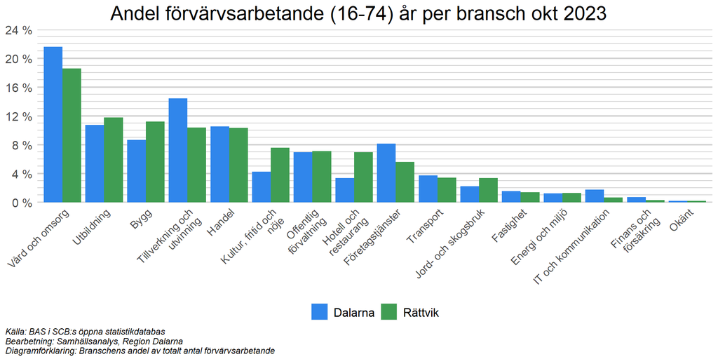

Baserat på branschgruppens andel av lönesumman inom det privata näringslivet i Rättvik är byggindustri störst, med ca 20 procent av den totala lönesumman. Få utrikes födda, få högutbildade och få kvinnor finns bland de sysselsatta inom branschgruppen. Även parti- och detaljhandel samt hotell och restaurang är viktiga branschgrupper, med tillsammans strax över 20 procent av den totala lönesumman. Den sistnämnda branschgruppen har en övervikt av kvinnor bland de sysselsatta, samt relativt många utrikes födda.

Den klart största arbetsgivaren i Rättvik var 2021 Rättviks Kommun med runt 1 200 anställda. Bland övriga arbetsgivare är de flesta avsevärt mindre.

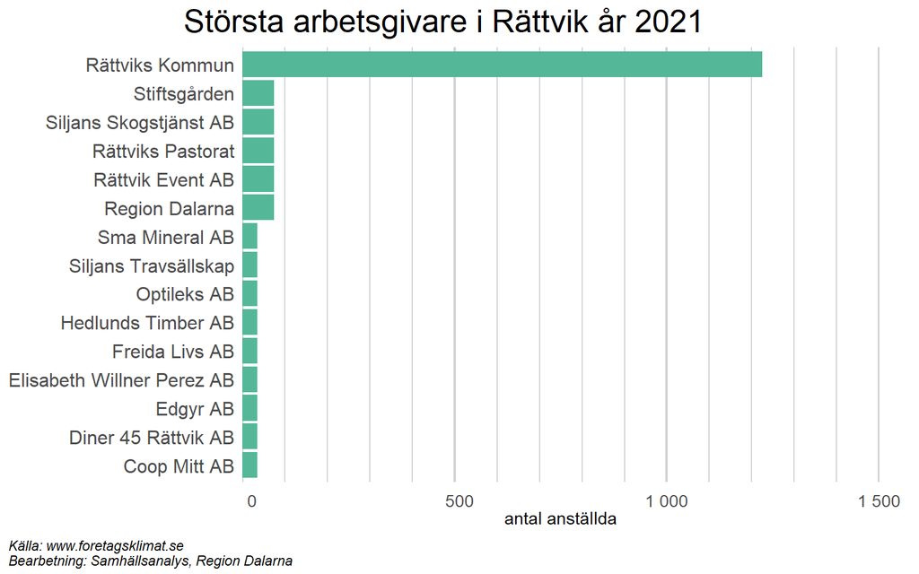

Rättvik tillhör Dalarnas bästa kommuner vad gäller antalet privata arbetsställen per 1000 invånare och har dessutom relativt få konkurser.

När det kommer till antalet företag som krävs för att den aggregerade lönesumman skall uppgå till 50 procent av den totala lönesumman är Rättvik tredje bäst i Dalarna. Trots att Borlänge har mer än 4 gånger så stor befolkning som Rättvik, krävs bara något färre antal företag för att uppnå 50 procent av lönesumman. Rättvik har således ett väldigt litet beroende av enskilda företag. Samtidigt bör man notera att företag inom byggbranschen står för ungefär 20 procent av lönesumman inom det privata näringslivet, varför Rättvik är relativt beroende av den branschen.

Sammanfattningsvis kan Rättvik sägas vara en kommun som uppvisar låg sårbarhet på de flesta områdena enligt vår modell, då arbetslösheten är låg och relativt många pendlar till andra kommuner. Dessutom har Rättvik ett lågt beroende av enskilda företag. Bland orosmolnen finns Dalarnas äldsta befolkning och ett visst beroende av företag inom branschgruppen byggindustri.

## Smedjebacken

Smedjebackens kommun hade ca 11 000 invånare år 2022. Befolkningen minskade ganska kraftigt mellan 1980 och 2000, men har därefter stabiliserats och till och med ökat något. Detta kan till viss del tillskrivas en ökad invandring, men även den inrikes födda befolkningen har ökat något det senaste decenniet. Arbetslösheten i Smedjebacken, 3.7 procent, är något lägre än genomsnittet i Dalarna, vilket även gäller utbildningsnivån. Smedjebacken är Dalarnas fjärde äldsta kommun, med en medelålder på mellan 46 och 47 år. Detta är exempelvis klart högre än närbelägna Ludvika. Smedjebacken är även en av Dalarnas största pendlarkommuner. Ungefär hälften av dem som bor i kommunen och förvärvsarbetar har sin arbetsplats i en annan kommun, Ludvika i stor utsträckning.

Som namnet antyder har Smedjebacken en lång historia kopplad till smedjor, men fungerade även länge som knutpunkt för land- och vattentransporter. Än idag är företag inom tillverkning och utvinning dominerande inom kommunen, ungefär var fjärde förvärvsarbetande arbetar inom sådana företag. Även arbetsgivare inom vård och omsorg är viktiga, med ca 23 procent av de förvärvsarbetande i kommunen.

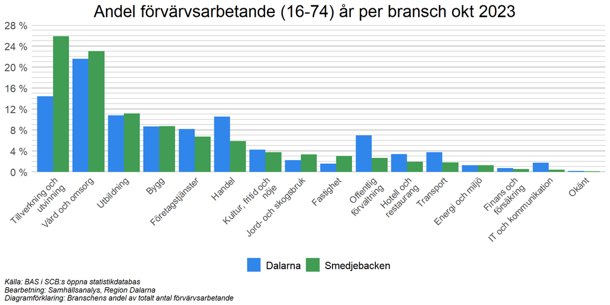

Den största privata arbetsgivaren i Smedjebacken finns inom branschgruppen stål- och metallverk . Branschens företag står för 25 procent av den totala lönesumman. Inom branschgruppen jobbar få utrikes födda och få kvinnor, och dessutom relativt få högutbildade. Även byggindustri och metallvaruindustri är viktiga branschgrupper sett till andel av lönesumman, och tillsammans med stål- och metallverk står dessa för ungefär halva lönesumman inom det privata näringslivet. Även företag inom branschgruppen företagsservicefirmor anställer relativt många men här återfinns en ganska stor andel kvinnor, högutbildade och utrikes födda.

Den största arbetsgivaren i Smedjebacken var 2021 Smedjebackens Kommun med runt 1 100 anställda. Bland privata arbetsgivare var Ovako störst, med bortåt 400 anställda.

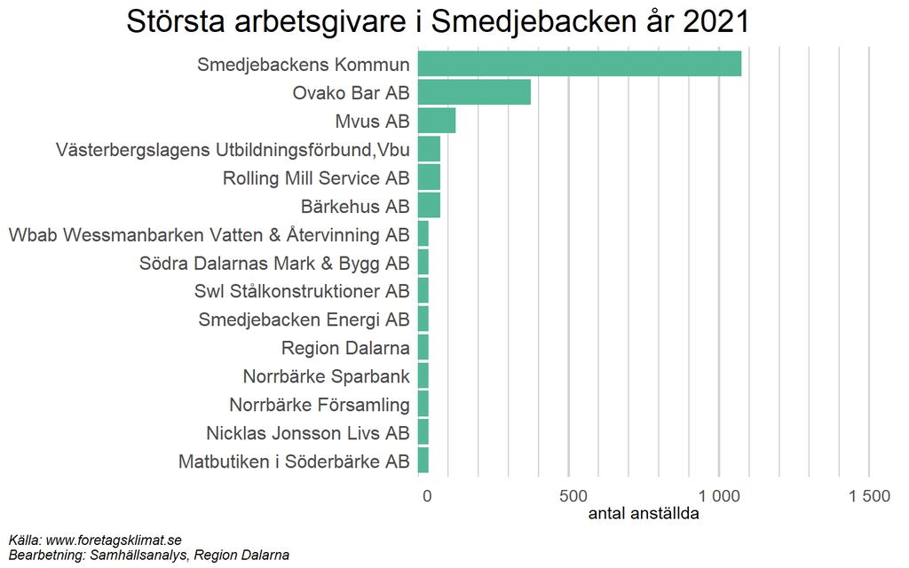

Smedjebacken har Dalarnas näst lägsta antal privata arbetsställen per 1 000 invånare och dessutom relativt många konkurser, vilka även har ökat på senare år.

Branschbredden i Smedjebacken är den lägsta i Dalarna och minskade dessutom från 2015 till 2021. Även antalet företag som utgör 50 procent av den aggregerade lönesumman är bland de lägsta i Dalarna (10), vilket indikerar att Smedjebacken är en kommun med relativt högt beroende. Visserligen är pendlingen hög, men denna pendling går i stor utsträckning till närbelägna Ludvika med en väldigt dominerande arbetsgivare.

Sammanfattningsvis kan Smedjebacken sägas vara en kommun som uppvisar sårbarhet på flera områden. Visserligen är arbetslösheten bara runt genomsnittet för Dalarna och kommunen har en stor utpendling, men den pendlingen går i stor uträckning till närbelägna Ludvika som domineras av en enskild arbetsgivare. Beroendet av enskilda företag och branscher i Smedjebacken är dessutom högt och det finns relativt få arbetsställen. Naturligtvis finns samtidigt positiva sidor med att ha en stor och expanderande arbetsgivare (Hitachi) bara någon mil bort.

## Säter

Säter tillhör en grupp med fem kommuner i Dalarna som har en folkmängd på mellan 10 000 och 11 000 invånare. Befolkningen ökade avsevärt från slutet av 1960-talet till 1990, men minskade därefter. På senare år har Säters befolkning återigen börjat öka, vilket kan tillskrivas såväl en ökning bland inrikes som utrikes födda invånare. Arbetslösheten i Säter, 2.8 procent, är klart lägre än genomsnittet i Dalarna, samtidigt som andelen högutbildade är något lägre än genomsnittet i Dalarna. Att arbetslösheten är låg kan delvis tillskrivas den relativt låga andelen utrikes födda i Säter, en grupp där arbetslösheten vanligtvis är högre än bland inrikes födda. Exempelvis har närbelägna Borlänge mer än dubbelt så stor andel utrikes födda och dessutom klart högre arbetslöshet. Medelåldern i Säter är relativt låg, ca 45 år, men samtidigt klart högre än i närbelägna Borlänge. Säter är, tillsammans med Gagnef, den kommun som har störst pendling i Dalarna, närmare 60 procent av dem som bor i Säter och förvärvsarbetar har sin arbetsplats på annan ort.

Säter fick stadsprivilegier redan på 1600-talet och är bland annat känt för Säters sjukhus, som under en period var Sveriges största mentalsjukshus. Idag arbetar en stor andel av de sysselsatta inom vård och omsorg, ungefär 32 procent av de förvärvsarbetande, vilket är den högsta andelen bland Dalarnas kommuner.

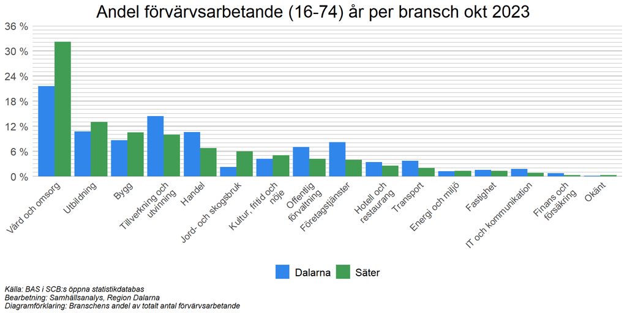

Baserat på andelen av lönesumman inom det privata näringslivet i Säter är byggindustri den största branschgruppen, med 21 procent av den totala lönesumman. Få utrikes födda, få högutbildade och få kvinnor är sysselsatta inom byggbranschen. Även parti- och detaljhandeln samt företagsservicefirmor är viktiga branschgrupper. I dessa båda finns en klart större andel kvinnor, högutbildade och utrikes födda bland de sysselsatta.

Den största arbetsgivaren i Säter var år 2021 Säters Kommun med strax under 1 300 anställda. Även Region Dalarna är en stor arbetsgivare, medan det inom det privata näringslivet bara finns ett företag med mer än 50 anställda (Gustafs Scandinavia).

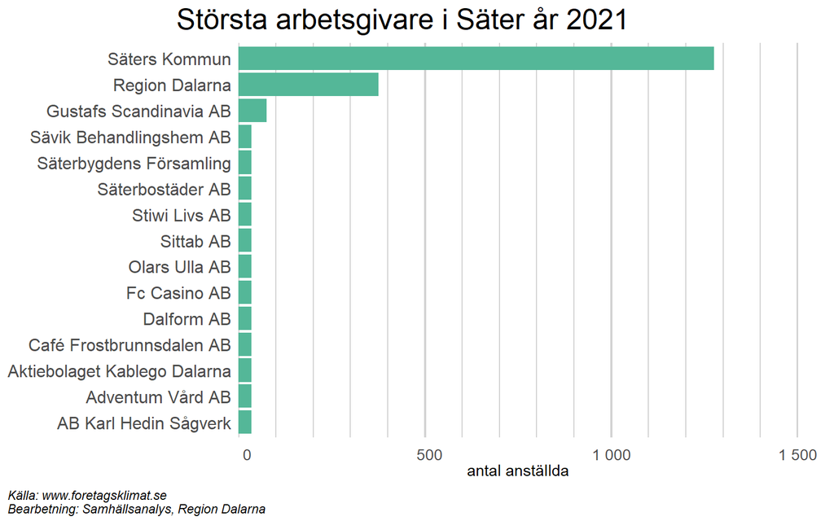

Antalet arbetsställen per 1 000 invånare i Säter är bland det lägsta i Dalarna, men samtidigt har antalet nystartade företag (per 1 000 invånare) ökat under en längre period och ligger idag över genomsnittet i Dalarna. Branschbredden i Säter är i linje med många andra kommuner av samma storlek, men antalet företag som krävs för att den aggregerade lönesumman skall uppgå till 50 procent av den totala lönesumman i det privata näringslivet (45) är avsevärt mycket större än många jämförbara kommuner. Säter kan därför sägas vara en kommun med relativt litet beroende. Samtidigt skall man vara medveten om att andelen som arbetar inom vård och omsorg i Säter (där många arbetsgivare tillhör det offentliga) är högst i Dalarna, vilket är ett annat typ av beroende.

Sammanfattningsvis är Säter en kommun med låg sårbarhet inom flera områden. Arbetslösheten är bland de lägre i Dalarna och det sker en stor pendling till framförallt närbelägna Borlänge. Dessutom är beroendet av enskilda företag och branscher, inom den privata sektorn, lågt. På minussidan finns en stor dominans av arbetsgivare inom vård och omsorg, vilket potentiellt kan vara en sårbarhet. Det är dock rimligt att tänka sig att företag inom offentliga verksamheter påverkas annorlunda än det privata näringslivet vid exempelvis en nedgång i konjunkturen, samtidigt som behovet av tjänster kopplade till vård och omsorg sannolikt kommer att öka i framtiden. Noterbart är även att bygg är en klart dominerande bransch inom det privata näringslivet, vilket potentiellt skulle kunna bli ett problem vid en lågkonjunktur.

## Vansbro

Vansbro är, med sina 6 800 invånare år 2022, Dalarnas minsta kommun. Befolkningen minskade stadigt fram till millennieskiftet, för att därefter stabiliseras. Detta kan i mångt och mycket tillskrivas en ökad andel av utrikes födda i befolkningen, men även den del av befolkningen som är födda i Sverige har minskat i långsammare takt på senare år. Vansbro har en av Dalarnas lägsta arbetslösheter, 2.5 procent, men samtidigt är det också den kommun som har lägst andel högutbildade. Att arbetslösheten är låg i Vansbro kan delvis tillskrivas den relativt låga andelen utrikes födda (under 10 procent), vilket är klart lägre än i många andra Dalakommuner. Pendlingen till och från kommunen tillhör länets lägsta, vilket kan ha att göra med kommunens geografiska läge i västra Dalarna.

Idag är Vansbro i första hand förknippat med ett antal större företag, såsom Lyko och Orkla, som står för en stor andel av de sysselsatta i kommunen. Detta återspeglas i figuren nedan, som visar att mer än 40 procent av Vansbros förvärvsarbetande arbetar inom tillverknings- och utvinningsbranschen samt handel.

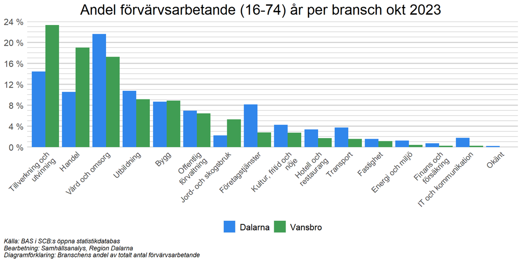

De största privata arbetsgivarna i Vansbro finns inom branschgruppen parti- och detaljhandel, vars företag står för drygt 23 procent av den totala lönesumman. Inom branschgruppen jobbar många kvinnor (>50 procent) och, i jämförelse med genomsnittet i Vansbro, många högutbildade. Bland övriga stora branschgrupper återfinns byggindustri och livsmedelsindustri, som tillsammans står för nästan 25 procent av den totala lönesumman. Den sistnämnda branschen har även den en majoritet kvinnor bland de anställda.

Den största arbetsgivaren i Vansbro var år 2021 Vansbro Kommun med ungefär 900 anställda. Inom det privata arbetslivet jobbade flest, drygt 350 fördelat på två företag, på Lyko.

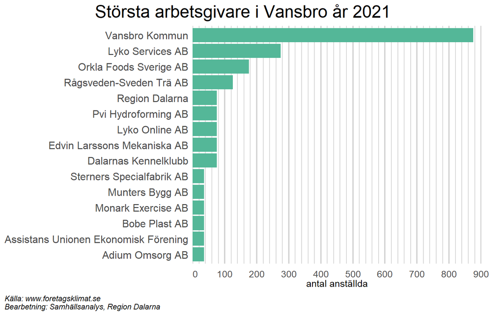

Vansbro är som sagt Dalarnas minsta kommun sett till befolkning och har följaktligen också en av de minsta branschbredderna i länet. Även antalet företag som utgör 50 procent av den aggregerade lönesumman är bland de lägsta i Dalarna (14), vilket indikerar att Vansbro är en kommun med relativt högt beroende. Samtidigt är antalet arbetsställen per 1 000 invånare högre i Vansbro än genomsnittet i Dalarna, vilket är positivt.

Sammanfattningsvis är Vansbro en kommun som uppvisar både sårbara och inte sårbara sidor. Arbetslösheten är låg, vilket indikerar en arbetsmarknad med god resiliens mot kriser. Samtidigt är Vansbro beroende av ett fåtal större företag inom ett par olika branscher, vilket är en riskfaktor. Dessutom är pendlingen relativt låg. Noterbart är dock att den största privata arbetsgivaren, Lyko, är ett familjeägt, och hittills expansivt, företag med en uttalad ambition att finnas i Vansbro.

## Älvdalen

Älvdalens kommun har länets tredje minsta folkmängd, med drygt 7 000 invånare år 2022. Precis som för många andra av Dalarnas mindre kommuner har befolkningen minskat under en längre period, en utveckling som har bromsat in på senare år. Detta kan i mångt och mycket tillskrivas en ökad invandring. Arbetslösheten, drygt 3.5 procent, är under genomsnittet i Dalarna, men samtidigt har Älvdalen näst lägst andel högutbildade. Att arbetslösheten är låg i Älvdalen kan delvis tillskrivas den relativt låga andelen utrikes födda (under 10 procent), vilket är klart lägre än i många andra Dalakommuner. Precis som för många andra kommuner i norra och västra Dalarna är pendlingen låg, ungefär var femte boende i Älvdalen som förvärvsarbetar gör det i en annan kommun.

Älvdalen är Dalarnas till ytan största kommun, mer än dubbelt så stor som Falun och Borlänge tillsammans. Kommunen är idag kanske mest känd för en omfattande turismindustri, som domineras av diverse aktörer i området kring Idre och Grövelsjön (“Kultur, fritid och nöje.” i figuren nedan). Kopplad till den “boom” som skett inom turismindustrin på senare år, har även byggsektorn expanderat och står för ungefär 13 procent av de förvärvsarbetande. I jämförelse med Dalarna sticker även företag inom jord- och skogsbruk ut, där dubbelt så stor andel arbetar jämfört med snittet i länet.

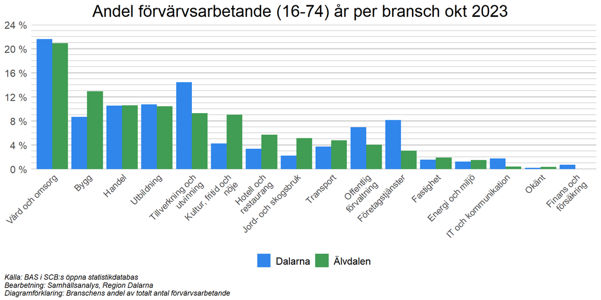

Baserat på branschgruppens andel av lönesumman inom det privata näringslivet i Älvdalen är byggindustri den största branschgruppen, med 19 procent av den totala lönesumman. Få utrikes födda, få högutbildade och få kvinnor är sysselsatta inom branschgruppen. Även företag inom renhållning, kultur, sport mm, som bland annat innefattar företag inom turism, har många anställda (410) och en relativt stor andel av lönesumman (ca 12 procent). Inom den branschgruppen är avsevärt många fler kvinnor, högutbildade och utrikes födda. Bland övriga stora branschgrupper kan parti- och detaljhandel nämnas, vars företag har ca 320 anställda och står för 10 procent av den totala lönesumman.

Den största arbetsgivaren i Älvdalen var år 2021 Älvdalens Kommun med närmare 800 anställda. Inom det privata näringslivet hade Idre Fjäll flest anställda, med strax över 200.

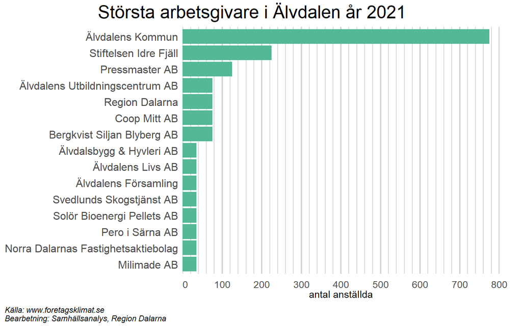

Befolkningsmässigt är Älvdalen en liten kommun och har följaktligen en låg branschbredd (ungefär en fjärdedel av branscherna finns representerade i kommunen). Dock är antalet företag som utgör 50 procent av den aggregerade lönesumman högre än i många jämförbara kommuner, vilket indikerar att Älvdalen inte är en kommun med överdrivet stort beroende. Älvdalen är dessutom den kommun i Dalarna där de startas flest nya företag per 1 000 invånare och kommunen har dessutom näst flest antal arbetsställen per 1 000 invånare. Baksidan är att Älvdalen samtidigt är den kommun som har flest antal konkurser per 1 000 invånare i Dalarna.

Sammanfattningsvis är Älvdalen en kommun som uppvisar låg sårbarhet på flera områden. Arbetslösheten är relativt låg samtidigt som beroendet av enskilda företag eller branscher inte är överdrivet stort. Det startas dessutom många företag i Älvdalens kommun, men samtidigt går relativt många företag i konkurs.

[^1]: https://www.regeringen.se/pressmeddelanden/2022/12/svantesson-utdragen-lagkonjunktur-star-for-dorren/
[^2]: https://www.regiondalarna.se/regionalutveckling/vart-uppdrag/projektverksamhet/k.r.o.k/
[^3]: https://tillvaxtverket.se/tillvaxtverket/publikationer/publikationer2022/kommunerssarbarhet2022.1448.html
[^4]: https://tillvaxtverket.se/tillvaxtverket/publikationer/publikationer2022/kommunerssarbarhet2022.1448.html
[^5]: https://www.regionhalland.se/app/uploads/2020/06/S%C3%A5rbarhetsanalys-av-n%C3%A4ringslivet-i-Halland_Region-Halland_april-2020.pdf
[^6]: https://www.regionvarmland.se/regionvarmland/utveckling-tillvaxt/hamta-material/rapportserien/sarbarhetsanalys-av-det-varmlandska-naringslivet
[^7]: Överenskommen veckoarbetstid, regionala tabeller, AKU, SCB
[^8]: https://tillvaxtverket.se/tillvaxtverket/publikationer/publikationer2022/kommunerssarbarhet2022.1448.html
[^9]: https://www.regionhalland.se/app/uploads/2020/06/S%C3%A5rbarhetsanalys-av-n%C3%A4ringslivet-i-Halland_Region-Halland_april-2020.pdf
[^10]: https://arbetsformedlingen.se/download/18.e4c7c0717f2869663d1681b/1656493289843/perspektiv-pa-langtidsarbetslosheten-2022-en-deskriptiv-analys.pdf
[^11]: https://www.nationalekonomi.se/sites/default/files/legacy/29-1-pl.pdf
[^12]: https://tillvaxtverket.se/tillvaxtverket/publikationer/publikationer2022/kommunerssarbarhet2022.1448.html
[^13]: https://tillvaxtverket.se/download/18.6855bfcf184896002ffc69/1668765916305/Kommuners%20s%C3%A5rbarhet%20vid%20f%C3%B6retagsnedl%C3%A4ggningar.pdf
[^14]: https://tillvaxtverket.se/tillvaxtverket/publikationer/publikationer2022/kommunerssarbarhet2022.1448.html
[^15]: https://www.regionhalland.se/app/uploads/2020/06/S%C3%A5rbarhetsanalys-av-n%C3%A4ringslivet-i-Halland_Region-Halland_april-2020.pdf
[^16]: https://www.regeringen.se/rapporter/2005/10/ess-20051/
[^17]: https://www.ifn.se/publikationer/working-papers/2021/1408/
[^18]: https://www.sciencedirect.com/science/article/abs/pii/S0038012119306809